# Homework 3: Classification - Analysis of Titanic data

Narjes Mathlouthi for PSTAT 131/231

## Classification

For this assignment, we will be working with part of a [Kaggle data set](https://www.kaggle.com/c/titanic/overview) that was the subject of a machine learning competition and is often used for practicing ML models. The goal is classification; specifically, to predict which passengers would survive the [Titanic shipwreck](https://en.wikipedia.org/wiki/Titanic).

Load the data from `data/titanic.csv` into *R* and familiarize yourself with the variables it contains using the codebook (`data/titanic_codebook.txt`).

Notice that `survived` and `pclass` should be changed to factors. When changing `survived` to a factor, you may want to reorder the factor so that *“Yes”* is the first level.

Make sure you load the `tidyverse` and `tidymodels`!

*Remember that you’ll need to set a seed at the beginning of the document to reproduce your results.*

```r
titanic_raw <- read_csv(here("data", "titanic.csv"))

titanic <- titanic_raw %>%
 mutate(pclass = as.factor(pclass)) %>%
  mutate(survived = as.factor(survived)) %>%
  mutate(ticket = as.numeric(ticket)) %>%
  select(-name)

titanic$survived <- recode_factor(titanic$survived, No = "yes", Yes = "no")
```

### Question 1

Split the data, stratifying on the outcome variable, `survived.` You should choose the proportions to split the data into. Verify that the training and testing data sets have the appropriate number of observations. Take a look at the training data and note any potential issues, such as missing data.

```r
#set a seed before splitting to ensure that we can reproduce the results
set.seed(3435)
#Split the data, stratifying on the outcome variable, `survived.`
titanic_split <- initial_split(titanic, strata =survived, prop = 0.7)

#training set
titanic_train <- training(titanic_split)

#testing set
titanic_test <- testing(titanic_split)

#Verify that the training and testing data sets have the appropriate number of observations
dim(titanic_train)
dim(titanic_test)


#What does missing data look like in our training set
#rowSums(is.na(titanic_train)) <= 0
```

[output not shown]

*Why is it a good idea to use stratified sampling for this data?*

The `strata` argument makes sure that both sides of the split have roughly the same distribution for each value of strata. If a numeric variable is passed to `strata`, then it is binned and distributions are matched within bins.

### Question 2

Using the **training** data set, explore/describe the distribution of the outcome variable `survived`.

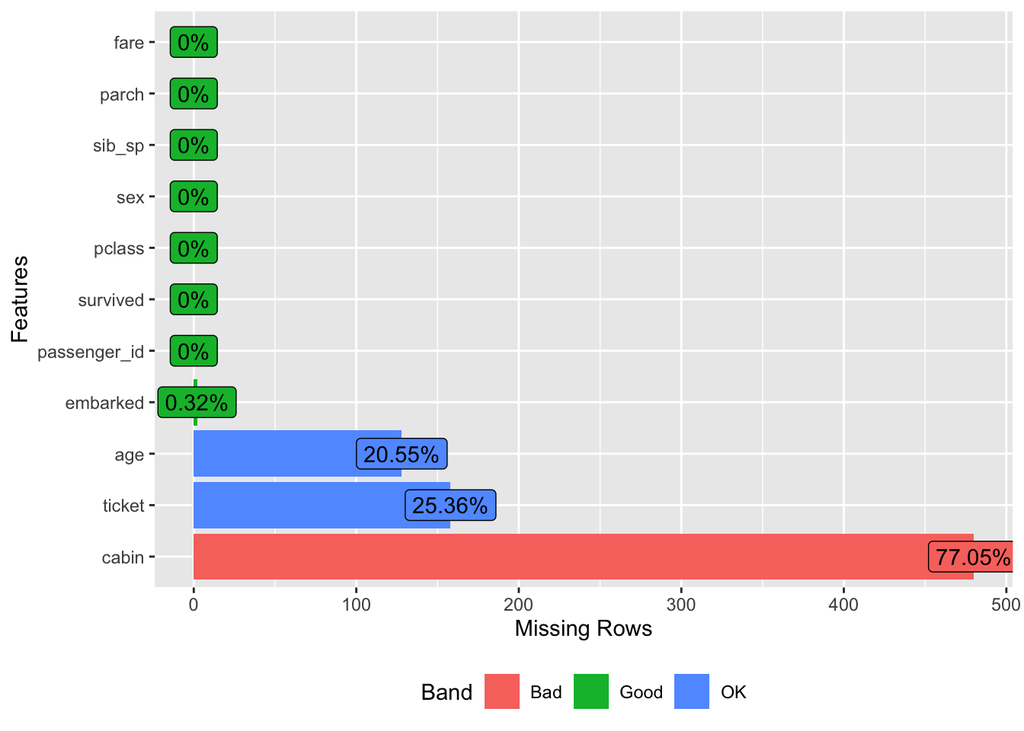

```r
titanic_train <- training(titanic_split)

#Looking at missing data
DataExplorer::plot_missing(
  titanic_train,
  group = list(Good = 0.05, OK = 0.4, Bad = 0.8, Remove = 1),
  missing_only = FALSE,
  geom_label_args = list(),
  title = NULL,
  ggtheme = theme_gray(),
  theme_config = list(legend.position = c("bottom"))
)
```

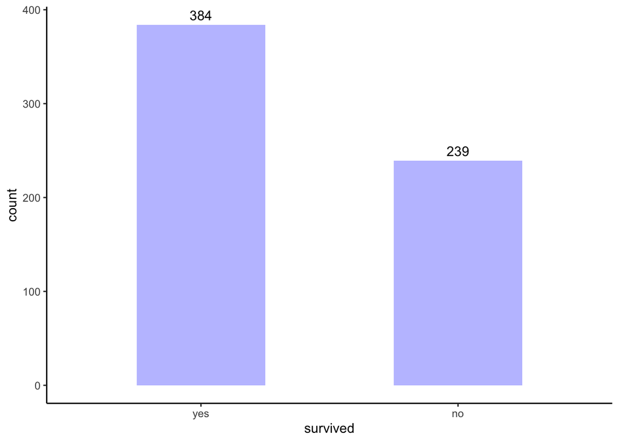

```r
ggplot(titanic_train, aes(x = survived)) +
  geom_bar(width=0.5, fill = "blue", alpha= 0.3) +
  geom_text(stat='count', aes(label=stat(count)), vjust=-0.5) +
  theme_classic()
```

- From **Figure1.** Graph of missing rows per variable, we can see that `survived` observations do not contain any **Na’s**
- From **Figure2.** Graph depicting survival rates among Titanic passengers

### Question 3

Using the **training** data set, create a correlation matrix of all continuous variables. Create a visualization of the matrix, and describe any patterns you see. Are any predictors correlated with each other? Which ones, and in which direction?

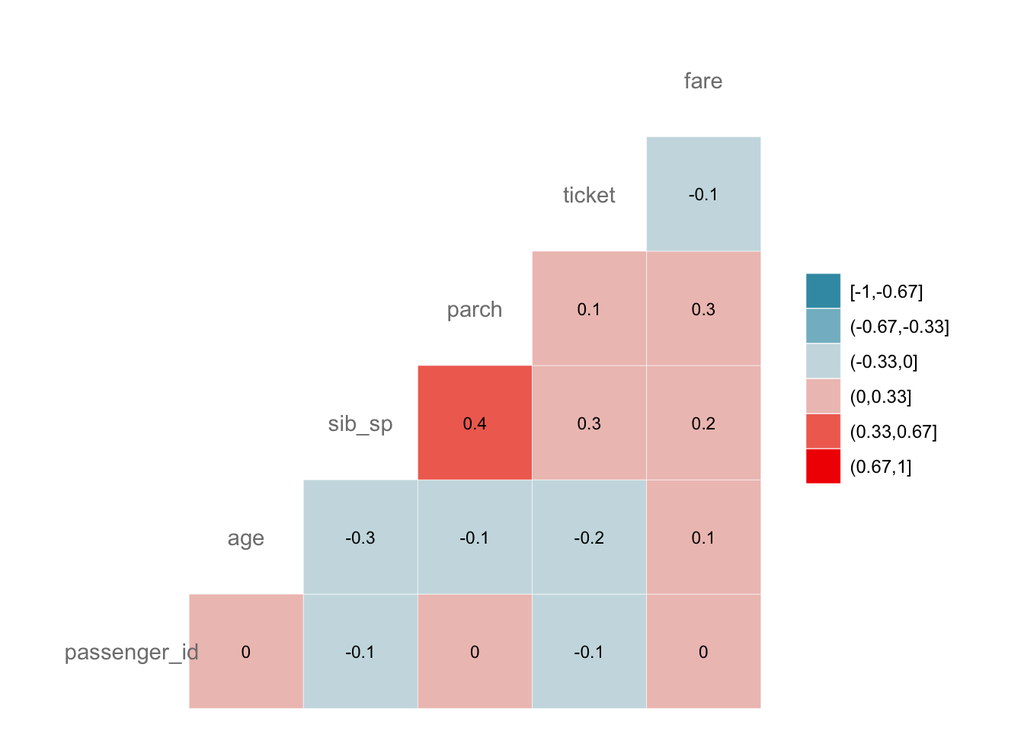

```r
ggcorr(titanic_train,
       nbreaks = 6,
       label = TRUE,
       label_size = 3,
       color = "grey50")
```

**Figure3. Correlation Matrix**

# of siblings / spouses aboard the Titanic is correlated with # of parents / children aboard the Titanic

### Question 4

Using the **training** data, create a recipe predicting the outcome variable `survived`. Include the following predictors: ticket class, sex, age, number of siblings or spouses aboard, number of parents or children aboard, and passenger fare.

Recall that there were missing values for `age`. To deal with this, add an imputation step using `step_impute_linear()`. Next, use `step_dummy()` to **dummy** encode categorical predictors. Finally, include interactions between:

- Sex and passenger fare, and
- Age and passenger fare.

You’ll need to investigate the `tidymodels` documentation to find the appropriate step functions to use.

```r
titanic_recipe <-
  recipe(survived ~ pclass + ticket + age + sib_sp +parch +fare , data = titanic_train) %>%
  step_impute_linear() %>%
  step_dummy() %>%
  step_interact(~ sex:fare + age:fare) # because a*b would generate a + b + a:b step_interact takes care of the interaction only
```

### Question 5

Specify a **logistic regression** model for classification using the `"glm"` engine. Then create a workflow. Add your model and the appropriate recipe. Finally, use `fit()` to apply your workflow to the **training** data.

*Hint: Make sure to store the results of `fit()`. You’ll need them later on.*

```r
glm_spec <- logistic_reg() %>%
  set_engine("glm")%>%
  set_mode("classification")
```

### Assessing Model Performance

We can use the model to generate probability predictions for the training data:

```r
predict(log_fit, new_data = titanic_train, type = "prob")
```

```
## # A tibble: 623 × 2
##    .pred_yes .pred_no
##        <dbl>    <dbl>
##  1    NA       NA
##  2    NA       NA
##  3     0.654    0.346
##  4     0.349    0.651
##  5     0.623    0.377
##  6    NA       NA
##  7    NA       NA
##  8     0.689    0.311
##  9     0.574    0.426
## 10    NA       NA
## # … with 613 more rows
```

Each row represents the probability predicted by the model that a given observation belongs to a given class. Notice this is redundant, because one could be calculated directly from the other, but it’s useful in multiclass situations.

However, it’s more useful to summarize the predicted values. We can use `augment()` to attach the predicted values to the daata, then generate a confusion matrix:

```r
augment(log_fit, new_data = titanic_train) %>%
  conf_mat(truth = survived, estimate = .pred_class)
```

```
##           Truth
## Prediction yes  no
##        yes 179  65
##        no   41  80
```

Or we can create a visual representation of the confusion matrix:

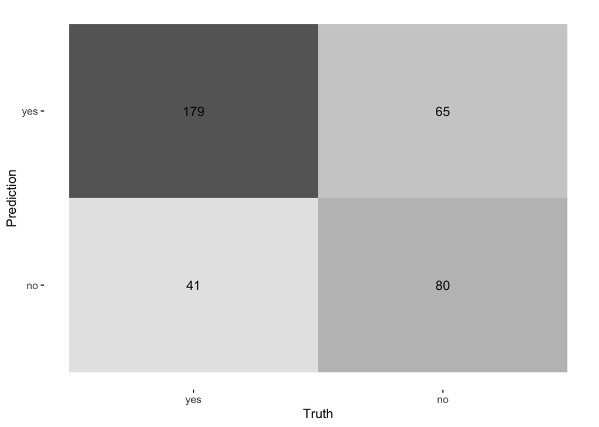

```r
augment(log_fit, new_data = titanic_train) %>%
  conf_mat(truth = survived, estimate = .pred_class) %>%
  autoplot(type = "heatmap")
```

Let’s calculate the accuracy of this model, or the average number of correct predictions it made on the **training** data. This is the model’s **training error rate**.

```r
log_reg_acc <- augment(log_fit, new_data = titanic_train) %>%
  accuracy(truth = survived, estimate = .pred_class)
log_reg_acc
```

```
## # A tibble: 1 × 3
##   .metric  .estimator .estimate
##   <chr>    <chr>          <dbl>
## 1 accuracy binary         0.710
```

### Question 6

**Repeat Question 5**, but this time specify a linear discriminant analysis model for classification using the `"MASS"` engine.

```r
lda_mod <- discrim_linear() %>%
  set_mode("classification") %>%
  set_engine("MASS")

lda_wkflow <- workflow() %>%
  add_model(lda_mod) %>%
  add_recipe(titanic_recipe)

lda_fit<-fit(lda_wkflow, titanic_train) #remove character 'name' and make tickert as numeric
```

### Assessing Performance

This can be done almost exactly the same way:

```r
predict(lda_fit, new_data = titanic_train, type = "prob")
```

```
## # A tibble: 623 × 2
##    .pred_yes .pred_no
##        <dbl>    <dbl>
##  1    NA       NA
##  2    NA       NA
##  3     0.673    0.327
##  4     0.357    0.643
##  5     0.602    0.398
##  6    NA       NA
##  7    NA       NA
##  8     0.713    0.287
##  9     0.588    0.412
## 10    NA       NA
## # … with 613 more rows
```

We can view a confidence matrix and calculate accuracy on the **training data**:

```r
augment(lda_fit, new_data = titanic_train) %>%
  conf_mat(truth = survived, estimate = .pred_class)
```

```
##           Truth
## Prediction yes  no
##        yes 177  66
##        no   43  79
```

```r
lda_acc <- augment(lda_fit, new_data = titanic_train) %>%
  accuracy(truth = survived, estimate = .pred_class)
lda_acc
```

```
## # A tibble: 1 × 3
##   .metric  .estimator .estimate
##   <chr>    <chr>          <dbl>
## 1 accuracy binary         0.701
```

### Question 7

**Repeat Question 5**, but this time specify a quadratic discriminant analysis model for classification using the `"MASS"` engine.

[output not shown]

### Assessing Performance

And again:

```r
predict(qda_fit, new_data = titanic_train, type = "prob")
```

```
## # A tibble: 623 × 2
##    .pred_yes .pred_no
##        <dbl>    <dbl>
##  1   NA        NA
##  2   NA        NA
##  3    0.521     0.479
##  4    0.288     0.712
##  5    0.333     0.667
##  6   NA        NA
##  7   NA        NA
##  8    0.753     0.247
##  9    0.0944    0.906
## 10   NA        NA
## # … with 613 more rows
```

We can view a confidence matrix and calculate accuracy on the **training data**:

```r
augment(qda_fit, new_data = titanic_train) %>%
  conf_mat(truth = survived, estimate = .pred_class)
```

```
##           Truth
## Prediction yes  no
##        yes 166  49
##        no  218 190
```

```r
qda_acc <- augment(qda_fit, new_data = titanic_train) %>%
  accuracy(truth = survived, estimate = .pred_class)
qda_acc
```

```
## # A tibble: 1 × 3
##   .metric  .estimator .estimate
##   <chr>    <chr>          <dbl>
## 1 accuracy binary         0.571
```

### Question 8

**Repeat Question 5**, but this time specify a naive Bayes model for classification using the `"klaR"` engine. Set the `usekernel` argument to `FALSE`.